# Reproducible Research: Peer Assessment 1

Daniel J. Riesco

18 September 2015

Loading and preprocessing the data removing objects and loading packages to use

```r
rm(list =ls())
library(knitr)
library(ggplot2)
```

Set up your working directory where the activity file is located and read the dataset

```r
setwd("C:/R Programming/research/data")
data <- read.csv("activity.csv")
```

look at data

```
## 'data.frame':    17568 obs. of  3 variables:
##  $ steps   : int  NA NA NA NA NA NA NA NA NA NA ...
##  $ date    : Factor w/ 61 levels "2012-10-01","2012-10-02",..: 1 1 1 1 1 1 1 1 1 1 ...
##  $ interval: int  0 5 10 15 20 25 30 35 40 45 ...
```

```
##      steps                date          interval
##  Min.   :  0.00   2012-10-01:  288   Min.   :   0.0
##  1st Qu.:  0.00   2012-10-02:  288   1st Qu.: 588.8
##  Median :  0.00   2012-10-03:  288   Median :1177.5
##  Mean   : 37.38   2012-10-04:  288   Mean   :1177.5
##  3rd Qu.: 12.00   2012-10-05:  288   3rd Qu.:1766.2
##  Max.   :806.00   2012-10-06:  288   Max.   :2355.0
##  NA's   :2304     (Other)   :15840
```

1.What is mean total number of steps taken per day?

Calculate the total number of steps taken per day through tapply function and plot the result

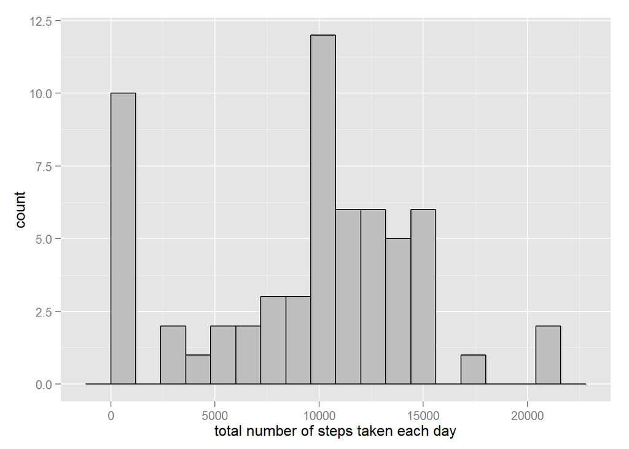

```r
steps_per_day <- tapply(data$steps, data$date, FUN=sum, na.rm=TRUE)
qplot(steps_per_day, binwidth=1200, xlab="total number of steps taken each day") +
        geom_histogram(binwidth=1200,colour="black", fill="grey")
```

Calculate and report the mean and median of the total number of steps taken per day

```r
mean(steps_per_day, na.rm=TRUE)
```

```
## [1] 9354.23
```

```r
median(steps_per_day, na.rm=TRUE)
```

```
## [1] 10395
```

2.What is the average daily activity pattern?

Make a time series plot (i.e. type = “l”) of the 5-minute interval (x-axis) and the average number of steps taken, averaged across all days (y-axis)

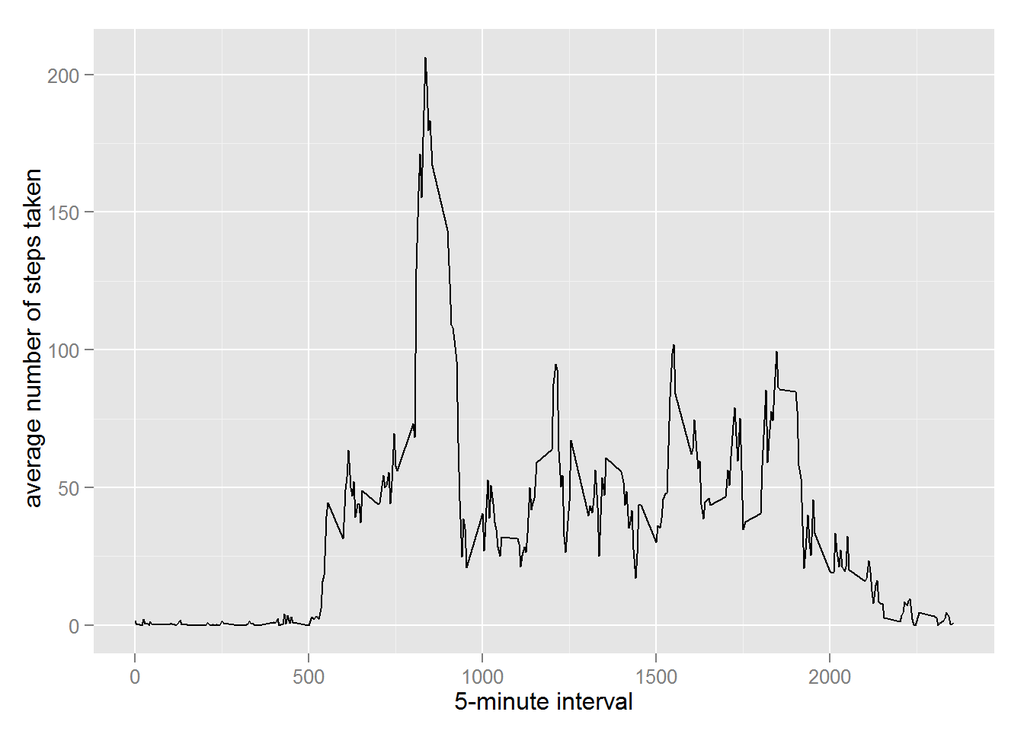

```r
averages_daily <- aggregate(x=list(steps=data$steps), by=list(interval=data$interval),
                      FUN=mean, na.rm=TRUE)
ggplot(data=averages_daily, aes(x=interval, y=steps)) +
    geom_line() +
    xlab("5-minute interval") +
    ylab(" average number of steps taken")
```

Which 5-minute interval, on average across all the days in the dataset, contains the maximum number of step Determines the location of maximum through which.max function subsetting a row of averages_daily data frame

```r
averages_daily[which.max(averages_daily$steps), ]
```

```
##     interval    steps
## 104      835 206.1698
```

3.Imputing missing values There are a number of days/intervals where there are missing values (coded as NA). The presence of missing days may introduce bias into some calculations or summaries of the data.

Calculate and report the total number of missing values in the dataset (i.e. the total number of rows with NAs)

```r
na <- is.na(data$steps)
table(na)
```

```
## na
## FALSE  TRUE
## 15264  2304
```

Devise a strategy for filling in all of the missing values in the dataset. The strategy does not need to be sophisticated. For example, you could use the mean/median for that day, or the mean for that 5-minute interval

```r
##### Replace each NA with the mean value of its 5-minute interval
fill_na <- function(steps, interval) {
    filled <- NA
    if (!is.na(steps))
        filled <- c(steps) else filled <- (averages_daily[averages_daily$interval == interval, "steps"])
    return(filled)
}
```

Create a new dataset that is equal to the original dataset but with the missing data filled in.

```r
filled_data <- data
filled_data$steps <- mapply(fill_na, filled_data$steps, filled_data$interval)
```

Make a histogram of the total number of steps taken each day and Calculate and report the mean and median total number of steps taken per day.

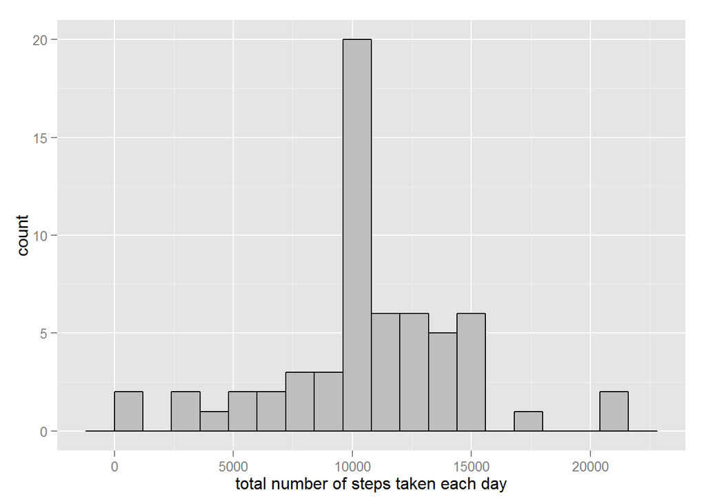

```r
total_steps <- tapply(filled_data$steps, filled_data$date, FUN = sum)
qplot(total_steps, binwidth = 1200, xlab = "total number of steps taken each day")+
        geom_histogram(binwidth=1200,colour="black", fill="grey")
```

```r
mean(total_steps)
```

```
## [1] 10766.19
```

```r
median(total_steps)
```

```
## [1] 10766.19
```

4.Are there differences in activity patterns between weekdays and weekends?

Create a new factor variable in the dataset with two levels - “weekday” and “weekend” indicating whether a given date is a weekday or weekend day

```r
weekday_vs_weekend <- function(date) {
    day <- weekdays(date)
    if (day %in% c("Monday", "Tuesday", "Wednesday", "Thursday", "Friday"))
        return("weekday") else if (day %in% c("Saturday", "Sunday"))
        return("weekend") else stop("invalid date")
}
```

```r
filled_data$date <- as.Date(filled_data$date)
filled_data$day <- sapply(filled_data$date, FUN = weekday_vs_weekend)
```

Make a panel plot containing a time series plot (i.e. type = “l”) of the 5-minute interval (x-axis) and the average number of steps taken, averaged across all weekday days or weekend days (y-axis). See the README file in the GitHub repository to see an example of what this plot should look like using simulated data

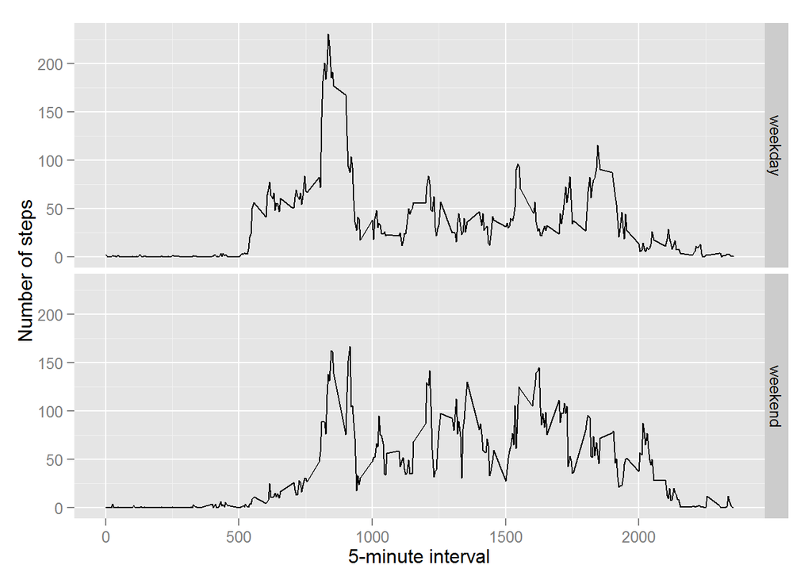

```r
averages <- aggregate(steps ~ interval + day, data = filled_data, mean)
ggplot(averages, aes(interval, steps)) + geom_line() + facet_grid(day ~ .) +
    xlab("5-minute interval") + ylab("Number of steps")
```